# Predicting Mice Tendicies through Stimulation

3/17/25

# Predicting Mice Tendicies through Stimulation

# Background

In this project, we analyze a subset of data collected by Steinmetz et al. (2019). While this document provides the basic understanding of the experiments, it is highly recommended that one consults the original publication for a more comprehensive understanding in order to improve the quality of the analysis report.

In the study conducted by Steinmetz et al. (2019), experiments were performed on a total of 10 mice over 39 sessions. Each session comprised several hundred trials, during which visual stimuli were randomly presented to the mouse on two screens positioned on both sides of it. The stimuli varied in terms of contrast levels, which took values in {0, 0.25, 0.5, 1}, with 0 indicating the absence of a stimulus. The mice were required to make decisions based on the visual stimuli, using a wheel controlled by their forepaws. A reward or penalty (i.e., feedback) was subsequently administered based on the outcome of their decisions. In particular,

- When left contrast > right contrast, success (1) if turning the wheel to the right and failure (-1) otherwise.
- When right contrast > left contrast, success (1) if turning the wheel to the left and failure (-1) otherwise.
- When both left and right contrasts are zero, success (1) if holding the wheel still and failure (-1) otherwise.
- When left and right contrasts are equal but non-zero, left or right will be randomly chosen (50%) as the correct choice.

The activity of the neurons in the mice’s visual cortex was recorded during the trials and made available in the form of spike trains, which are collections of timestamps corresponding to neuron firing. In this project, we focus specifically on the spike trains of neurons from the onset of the stimuli to 0.4 seconds post-onset. In addition, we only use 18 sessions (Sessions 1 to 18) from four mice: Cori, Frossman, Hence, and Lederberg.

# Data structure

A total of 18 RDS files are provided that contain the records from 18 sessions. In each RDS file, you can find the name of mouse from `mouse_name` and date of the experiment from `date_exp`.

```r
session=list()
for(i in 1:18){
  session[[i]]=readRDS(paste('./Data/session',i,'.rds',sep=''))
  #print(session[[i]]$mouse_name)
  #print(session[[i]]$date_exp)
}
```

# Question of interest

The primary objective of this project is to build a predictive model to predict the outcome (i.e., feedback type) of each trial using the neural activity data (i.e., spike trains in `spks`), along with the stimuli (the left and right contrasts). Given the complexity of the data (and that this is a course project), we break the predictive modeling into three parts as follows.

Part 1. Exploratory data analysis. In this part, we will explore the features of the data sets in order to build our prediction model. In particular, we would like to (i) describe the data structures across sessions (e.g., number of neurons, number of trials, stimuli conditions, feedback types), (ii) explore the neural activities during each trial, (iii) explore the changes across trials, and (iv) explore homogeneity and heterogeneity across sessions and mice.

Part 2. Data integration. Using the findings in Part 1, we will propose an approach to combine data across trials by (i) extracting the shared patters across sessions and/or (ii) addressing the differences between sessions. The goal of this part is to enable the borrowing of information across sessions to enhance the prediction performance in Part 3.

Part 3. Model training and prediction. Finally, we will build a prediction model to predict the outcome (i.e., feedback types). The performance will be evaluated on two test sets of 100 trials randomly selected from Session 1 and Session 18, respectively. The test sets will be released on the day of submission when you need to evaluate the performance of your model.

# Abstract

Some things that could be improved, is a more detailed analysis on the EDA portion. Instead of bar graphs, boxplots or cluster graphs could be used as well. Combining the sessions by mice name and ignoring the date as factor could be further in this model. This could help better visualize the importance of each variable. In addition figuring out if brain area affects the success rate or not could be found if the brain area data set was decreased. Another predicitive model could’ve been used as well such as XGBoost.

# Introduction

In this project, an experiment is conducted on mice to see how they responded to certain stimuli in the left and right side of their brain by turning a wheel. We will build a predictive model to predict the outcome of feedback type using the neural activity data with variables such as the number of spikes and brain area, as well as the stimuli. Five variables are available for each trial, namely: - `feedback_type`: type of the feedback, 1 for success and -1 for failure - `contrast_left`: contrast of the left stimulus, if contrast left > contrast right and the wheel is turned to the right,it is a success, otherwise it is a failure. - `contrast_right`: contrast of the right stimulus, if contrast right > contrast left and the wheel is turned to the left, it is a sucecess, otherwise it is a failure. If both contrasts is 0, the success depends on whether or not the mice is holding the wheel still. If both contrasts are equal but not zero, one is chosen through 50%. - `time`: centers of the time bins for `spks`  
- `spks`: numbers of spikes of neurons in the visual cortex in time bins defined in `time` - `brain_area`: area of the brain where each neuron lives. The prediction will be based on the total amount of feedback_type across all 18 sessions, the average spikes, and the decision of the mice stimuli.

First, I separated each session into each session by number, 1-18. I then created a data frame with all the variables with similar length so I can view the relationship between certain variables. These variables iunclude spks: number of spikes in time, time, contrast_left and contrast_right, and feedback_type. I also wanted to see what the most common brain area where the neuron lived. The date can be ignored as the factor of the date should not impact feedback. The first three mice names are Cori, followed by the next four which are Forssmann, followed by the next four, Hench, and followed by the last seven, Lederberg.

# Session 1:

The most common brain_area was VISp with 178. With the average spikes at 0.038. There were more success in this session than failures. The mice name was Cori.

```r
s1 = session[[1]]
summary(s1)
```

```
##                Length Class  Mode
## contrast_left  114    -none- numeric
## contrast_right 114    -none- numeric
## feedback_type  114    -none- numeric
## mouse_name       1    -none- character
## brain_area     734    -none- character
## date_exp         1    -none- character
## spks           114    -none- list
## time           114    -none- list
```

```r
brain_area = data.frame(s1$brain_area)
brain_area %>% count(s1$brain_area, sort = TRUE)
```

```
##   s1$brain_area   n
## 1          VISp 178
## 2            LS 139
## 3           MOs 113
## 4           ACA 109
## 5           SUB  75
## 6           CA3  68
## 7            DG  34
## 8          root  18
```

```r
table(s1$brain_area)
```

```
##
##  ACA  CA3   DG   LS  MOs root  SUB VISp
##  109   68   34  139  113   18   75  178
```

```r
spks = as.numeric(unlist(s1$spks))
time = as.numeric(unlist(s1$time))
df = data.frame(spks, time,contrast_left = s1$contrast_left, contrast_right = s1$contrast_right, feedback_type = s1$feedback_type)
count(df, spks)
```

```
##   spks       n
## 1    0 3226790
## 2    1  112884
## 3    2    6476
## 4    3     644
## 5    4     172
## 6    5      69
## 7    6       5
```

```r
mean(spks)
```

```
## [1] 0.03849102
```

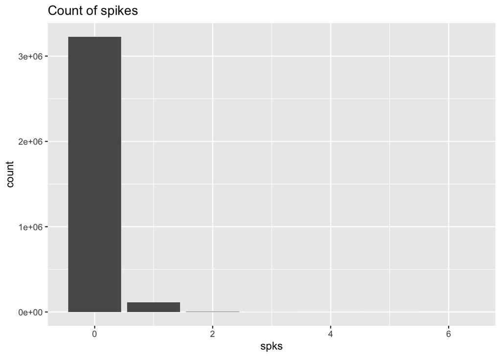

```r
ggplot(df) + geom_bar(mapping = aes(x=spks)) + labs(title = "Count of spikes")
```

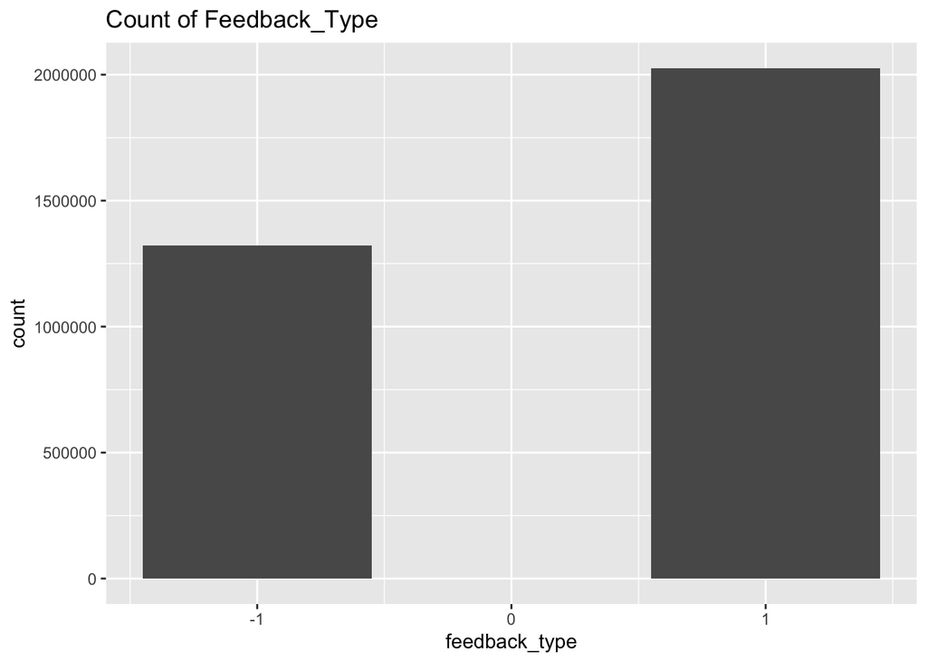

```r
ggplot(df) + geom_bar(mapping = aes(x=feedback_type)) + labs(title = "Count of Feedback_Type")
```

# Session 2: The most common brain_area was VISpm with 302. With the average spikes at 0.032. There were more success in this session than failures. The mice name was Cori.

```r
s2 = session[[2]]
summary(s2)
```

```
##                Length Class  Mode
## contrast_left   251   -none- numeric
## contrast_right  251   -none- numeric
## feedback_type   251   -none- numeric
## mouse_name        1   -none- character
## brain_area     1070   -none- character
## date_exp          1   -none- character
## spks            251   -none- list
## time            251   -none- list
```

```r
brain_area = data.frame(s2$brain_area)
brain_area %>% count(s2$brain_area, sort = TRUE)
```

```
##   s2$brain_area   n
## 1         VISpm 302
## 2          VISl 231
## 3          POST 191
## 4           CA1 190
## 5          root 156
```

```r
table(s2$brain_area)
```

```
##
##   CA1  POST  root  VISl VISpm
##   190   191   156   231   302
```

```r
spks = as.numeric(unlist(s2$spks))
time = as.numeric(unlist(s2$time))
df = data.frame(spks, time,contrast_left = s2$contrast_left, contrast_right = s2$contrast_right, feedback_type = s2$feedback_type)
count(df, spks)
```

```
##   spks        n
## 1    0 10420493
## 2    1   306198
## 3    2    14768
## 4    3     1211
## 5    4      111
## 6    5       17
## 7    6        1
## 8    9        1
```

```r
mean(spks)
```

```
## [1] 0.03164082
```

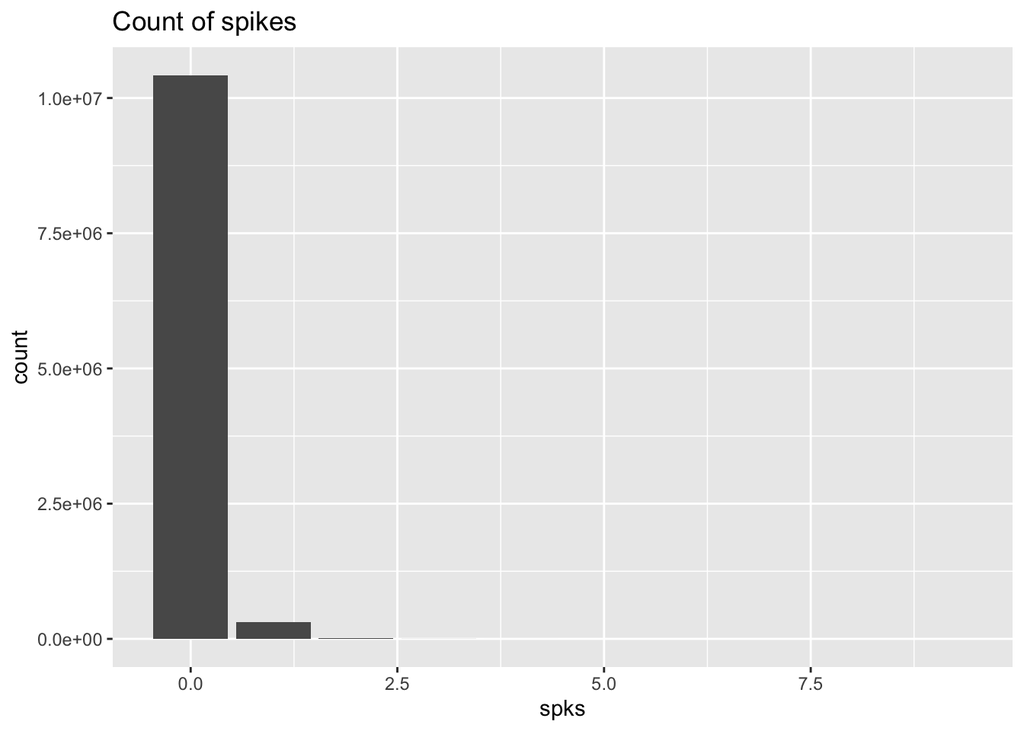

```r
ggplot(df) + geom_bar(mapping = aes(x=spks)) + labs(title = "Count of spikes")
```

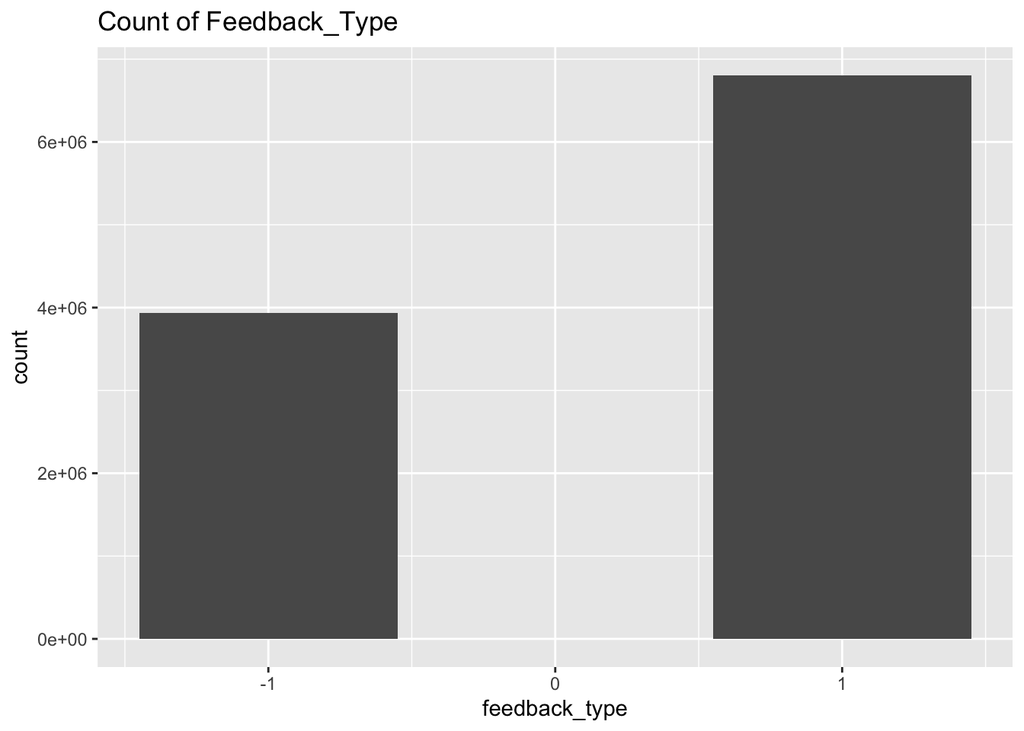

```r
ggplot(df) + geom_bar(mapping = aes(x=feedback_type)) + labs(title = "Count of Feedback_Type")
```

# Session 3: The most common brain_area was MG with 137. With the average spikes at 0.056. There were more success in this session than failures. The mice name was Cori.

```r
s3 = session[[3]]
summary(s3)
```

```
##                Length Class  Mode
## contrast_left  228    -none- numeric
## contrast_right 228    -none- numeric
## feedback_type  228    -none- numeric
## mouse_name       1    -none- character
## brain_area     619    -none- character
## date_exp         1    -none- character
## spks           228    -none- list
## time           228    -none- list
```

```r
spks = as.numeric(unlist(s3$spks))
time = as.numeric(unlist(s3$time))
brain_area = data.frame(s3$brain_area)
brain_area %>% count(s3$brain_area, sort = TRUE)
```

```
##    s3$brain_area   n
## 1             MG 137
## 2          VISam 114
## 3           VISp 114
## 4           POST  63
## 5             NB  43
## 6            CA1  42
## 7            MRN  41
## 8             DG  34
## 9            SPF  15
## 10          root  12
## 11            LP   4
```

```r
df = data.frame(spks, time,contrast_left = s3$contrast_left, contrast_right = s3$contrast_right, feedback_type = s3$feedback_type)
count(df, spks)
```

```
##   spks       n
## 1    0 5351999
## 2    1  273642
## 3    2   17658
## 4    3    1652
## 5    4     279
## 6    5      50
```

```r
mean(spks)
```

```
## [1] 0.05584843
```

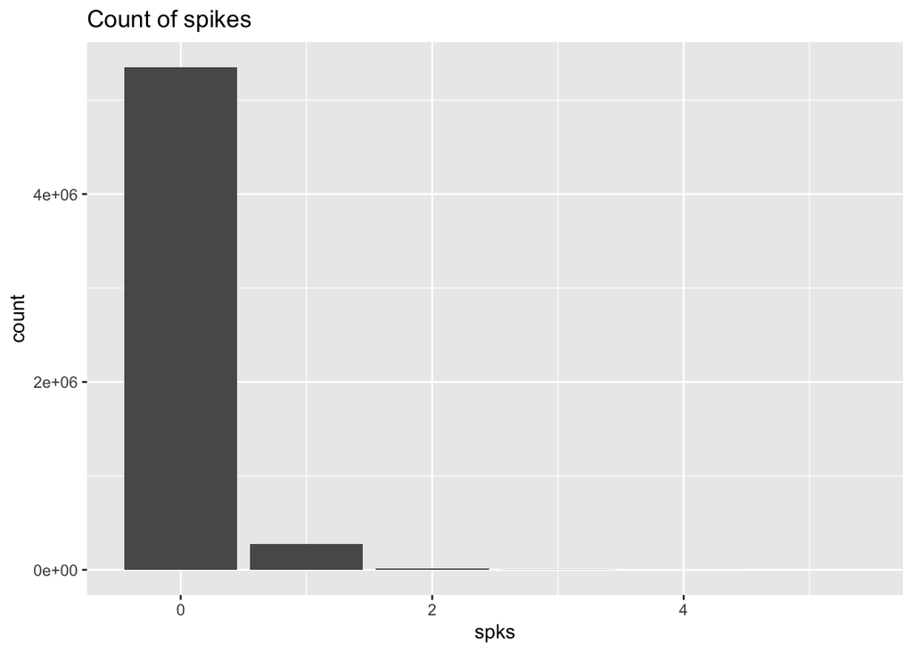

```r
ggplot(df) + geom_bar(mapping = aes(x=spks)) + labs(title = "Count of spikes")
```

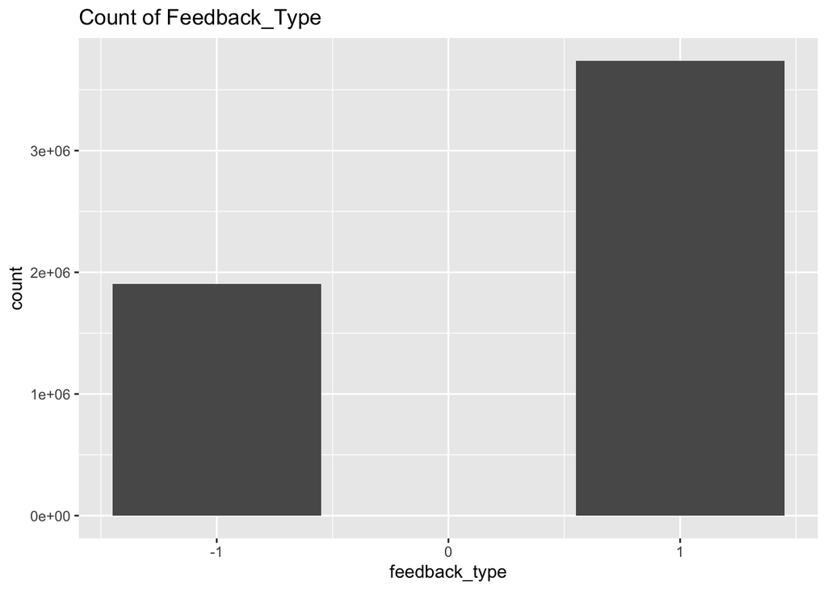

```r
ggplot(df) + geom_bar(mapping = aes(x=feedback_type)) + labs(title = "Count of Feedback_Type")
```

# Session 4: The most common brain_area was LSr with 435. With the average spikes at 0.021. There were more success in this session than failures. The mice name was Forssmann.

```r
s4 = session[[4]]
summary(s4)
```

```
##                Length Class  Mode
## contrast_left   249   -none- numeric
## contrast_right  249   -none- numeric
## feedback_type   249   -none- numeric
## mouse_name        1   -none- character
## brain_area     1769   -none- character
## date_exp          1   -none- character
## spks            249   -none- list
## time            249   -none- list
```

```r
spks = as.numeric(unlist(s4$spks))
time = as.numeric(unlist(s4$time))
brain_area = data.frame(s4$brain_area)
brain_area %>% count(s4$brain_area, sort = TRUE)
```

```
##    s4$brain_area   n
## 1            LSr 435
## 2            ACA 304
## 3             TH 256
## 4             DG 144
## 5            LGd 140
## 6            SUB 108
## 7            CA1  98
## 8            MOs  92
## 9           VISa  81
## 10           VPL  72
## 11          VISp  39
```

```r
df = data.frame(spks, time, contrast_left = s4$contrast_left, contrast_right = s4$contrast_right, feedback_type = s4$feedback_type)
count(df, spks)
```

```
##   spks        n
## 1    0 17266103
## 2    1   337916
## 3    2    13388
## 4    3     1450
## 5    4      298
## 6    5       62
## 7    6       17
## 8    7        5
## 9    8        1
```

```r
mean(spks)
```

```
## [1] 0.02103888
```

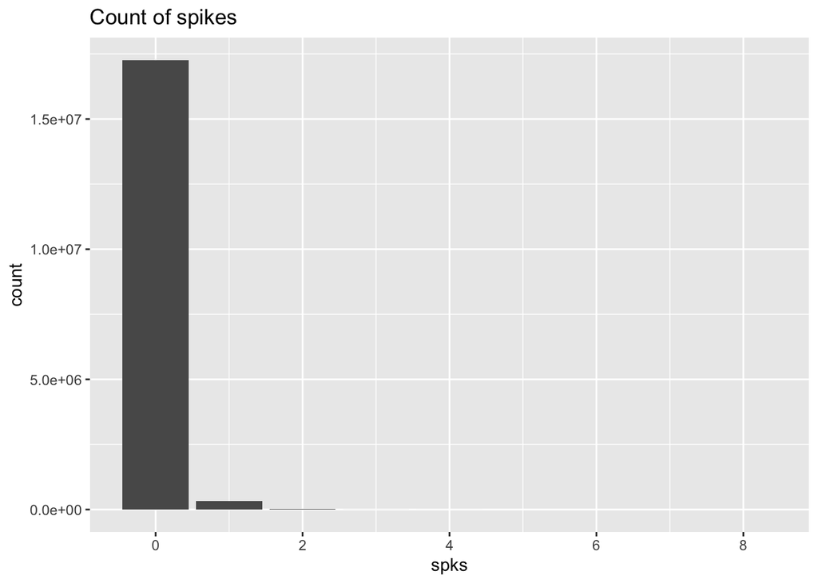

```r
ggplot(df) + geom_bar(mapping = aes(x=spks)) + labs(title = "Count of spikes")
```

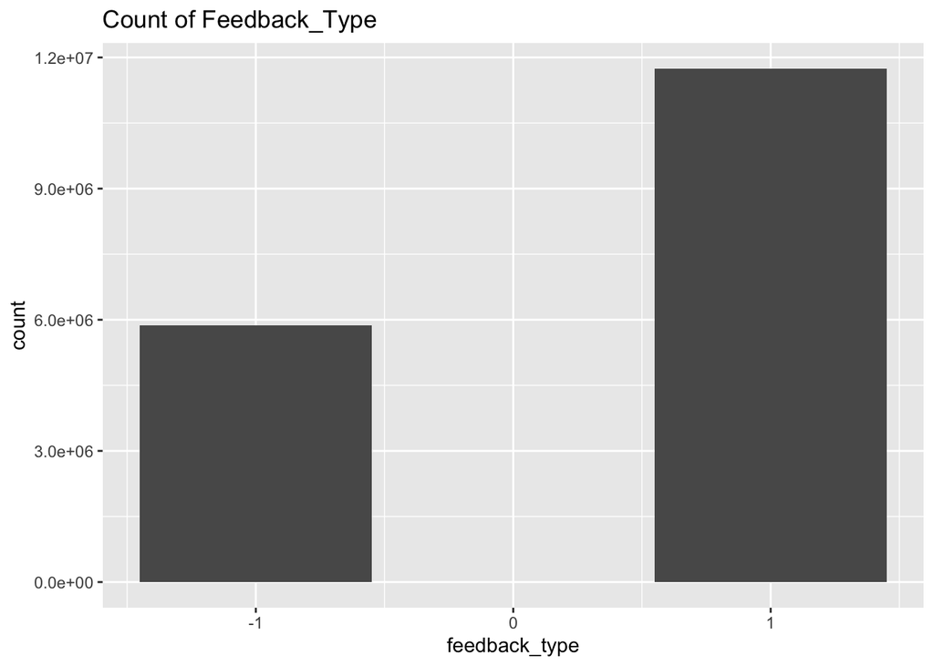

```r
ggplot(df) + geom_bar(mapping = aes(x=feedback_type)) + labs(title = "Count of Feedback_Type")
```

# Session 5: The most common brain_area was root with 524. With the average spikes at 0.028. There were more success in this session than failures. The mice name was Forssmann.

```r
s5 = session[[5]]
summary(s5)
```

```
##                Length Class  Mode
## contrast_left   254   -none- numeric
## contrast_right  254   -none- numeric
## feedback_type   254   -none- numeric
## mouse_name        1   -none- character
## brain_area     1077   -none- character
## date_exp          1   -none- character
## spks            254   -none- list
## time            254   -none- list
```

```r
spks = as.numeric(unlist(s5$spks))
time = as.numeric(unlist(s5$time))
brain_area = data.frame(s5$brain_area)
brain_area %>% count(s5$brain_area, sort = TRUE)
```

```
##    s5$brain_area   n
## 1           root 524
## 2            OLF 181
## 3            SUB 101
## 4           VISa  99
## 5            ACA  53
## 6            ORB  32
## 7            MOs  29
## 8            CA1  28
## 9             DG  16
## 10            PL  14
```

```r
df = data.frame(spks, time, contrast_left = s5$contrast_left, contrast_right = s5$contrast_right,feedback_type = s5$feedback_type)
count(df, spks)
```

```
##   spks        n
## 1    0 10655916
## 2    1   268678
## 3    2    16666
## 4    3     1010
## 5    4       46
## 6    5        4
```

```r
mean(spks)
```

```
## [1] 0.02789573
```

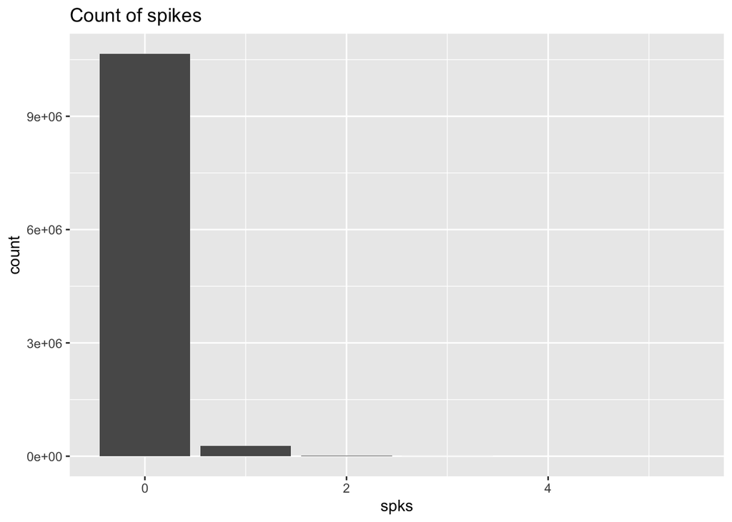

```r
ggplot(df) + geom_bar(mapping = aes(x=spks)) + labs(title = "Count of spikes")
```

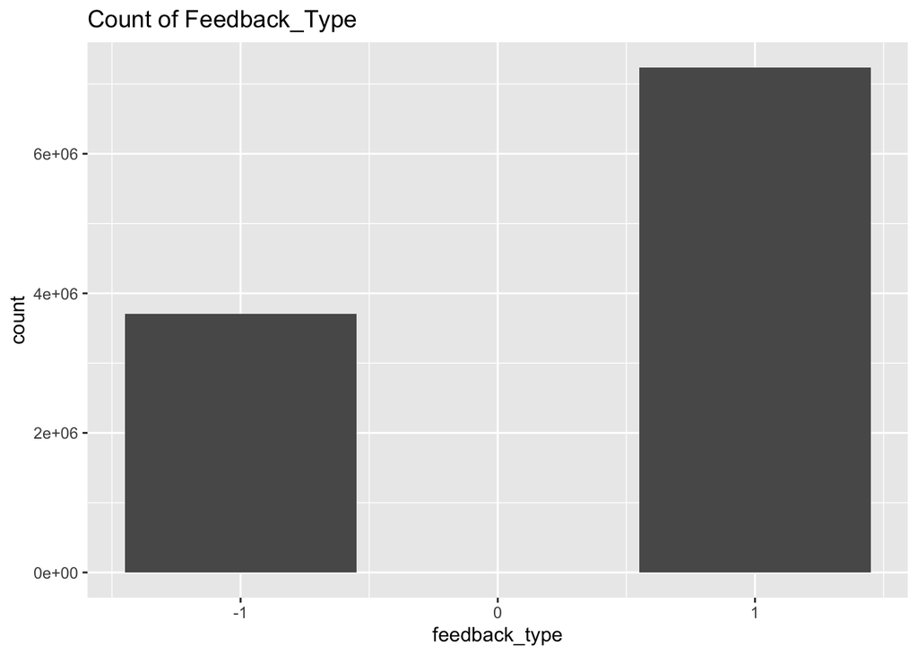

```r
ggplot(df) + geom_bar(mapping = aes(x=feedback_type)) + labs(title = "Count of Feedback_Type")
```

# Session 6: The most common brain_area was root with 628. With the average spikes at 0.017. There were more success in this session than failures. The mice name was Forssmann.

```r
s6 = session[[6]]
summary(s6)
```

```
##                Length Class  Mode
## contrast_left   290   -none- numeric
## contrast_right  290   -none- numeric
## feedback_type   290   -none- numeric
## mouse_name        1   -none- character
## brain_area     1169   -none- character
## date_exp          1   -none- character
## spks            290   -none- list
## time            290   -none- list
```

```r
spks = as.numeric(unlist(s6$spks))
time = as.numeric(unlist(s6$time))
brain_area = data.frame(s6$brain_area)
brain_area %>% count(s6$brain_area, sort = TRUE)
```

```
##   s6$brain_area   n
## 1          root 628
## 2            TH 248
## 3           AUD 246
## 4           CA1  36
## 5           SSp  11
```

```r
df = data.frame(spks, time, contrast_left = s6$contrast_left, contrast_right = s6$contrast_right, feedback_type = s6$feedback_type)
count(df, spks)
```

```
##   spks        n
## 1    0 13344186
## 2    1   208359
## 3    2     7182
## 4    3      600
## 5    4       66
## 6    5        2
## 7    6        4
## 8    7        1
```

```r
mean(spks)
```

```
## [1] 0.01657975
```

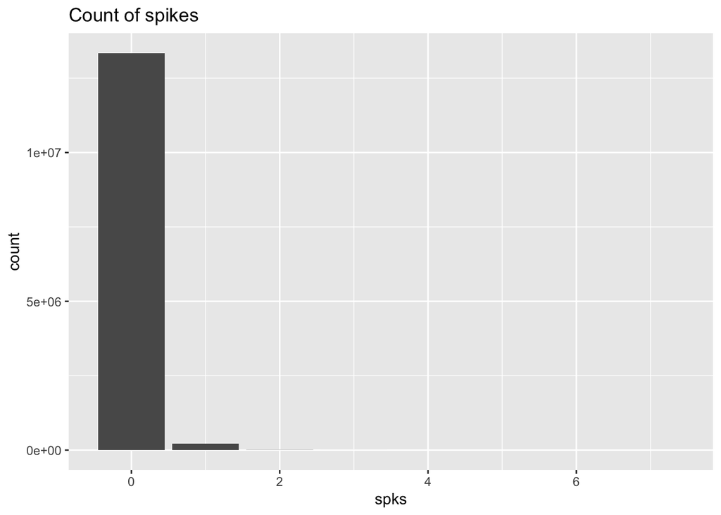

```r
ggplot(df) + geom_bar(mapping = aes(x=spks)) + labs(title = "Count of spikes")
```

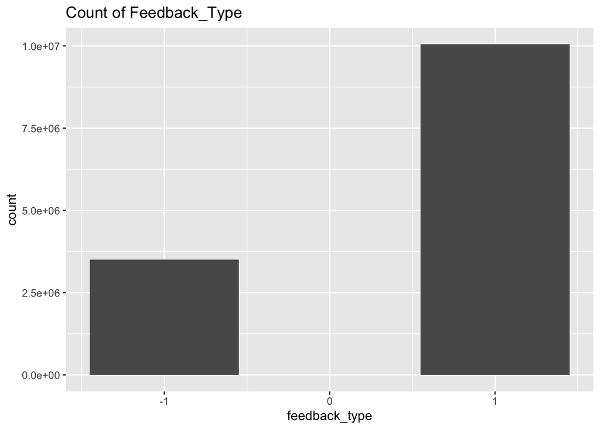

```r
ggplot(df) + geom_bar(mapping = aes(x=feedback_type)) + labs(title = "Count of Feedback_Type")
```

# Session 7: The most common brain_area was CA3 with 130. With the average spikes at 0.035. There were more success in this session than failures. The mice name was Forssmann.

```r
s7 = session[[7]]
summary(s7)
```

```
##                Length Class  Mode
## contrast_left  252    -none- numeric
## contrast_right 252    -none- numeric
## feedback_type  252    -none- numeric
## mouse_name       1    -none- character
## brain_area     584    -none- character
## date_exp         1    -none- character
## spks           252    -none- list
## time           252    -none- list
```

```r
spks = as.numeric(unlist(s7$spks))
time = as.numeric(unlist(s7$time))
brain_area = data.frame(s7$brain_area)
brain_area %>% count(s7$brain_area, sort = TRUE)
```

```
##   s7$brain_area   n
## 1           CA3 130
## 2           VPL 106
## 3          root  89
## 4           PIR  67
## 5            CP  59
## 6           EPd  52
## 7            LD  42
## 8           SSp  39
```

```r
df = data.frame(spks, time, contrast_left = s7$contrast_left, contrast_right = s7$contrast_right, feedback_type = s7$feedback_type
  )
count(df, spks)
```

```
##   spks       n
## 1    0 5703234
## 2    1  164033
## 3    2   15198
## 4    3    3292
## 5    4     825
## 6    5     135
## 7    6       3
```

```r
mean(spks)
```

```
## [1] 0.03538439
```

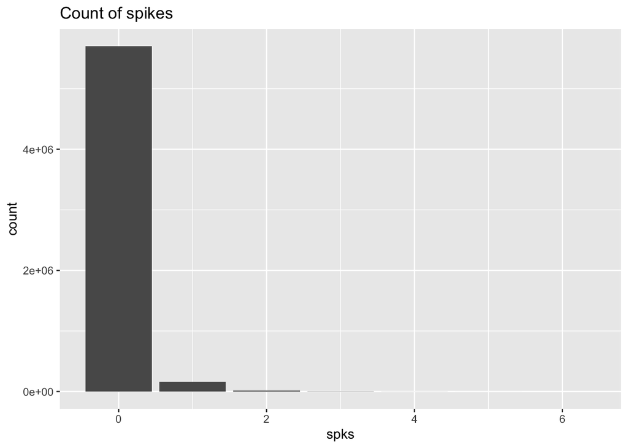

```r
ggplot(df) + geom_bar(mapping = aes(x=spks)) + labs(title = "Count of spikes")
```

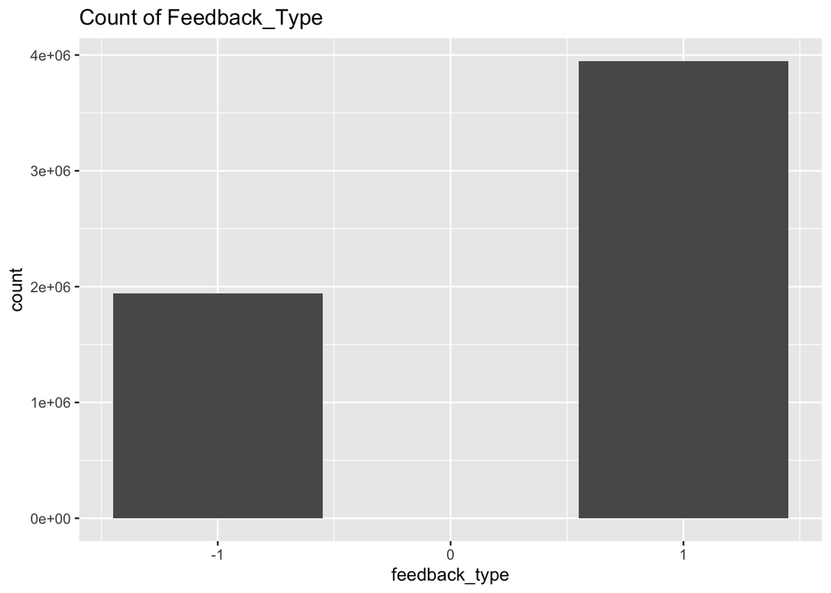

```r
ggplot(df) + geom_bar(mapping = aes(x=feedback_type)) + labs(title = "Count of Feedback_Type")
```

# Session 8: The most common brain_area was PO with 255. With the average spikes at 0.041. There were more success in this session than failures. The mice name was Hench.

```r
s8 = session[[8]]
summary(s8)
```

```
##                Length Class  Mode
## contrast_left   250   -none- numeric
## contrast_right  250   -none- numeric
## feedback_type   250   -none- numeric
## mouse_name        1   -none- character
## brain_area     1157   -none- character
## date_exp          1   -none- character
## spks            250   -none- list
## time            250   -none- list
```

```r
spks = as.numeric(unlist(s8$spks))
time = as.numeric(unlist(s8$time))
brain_area = data.frame(s8$brain_area)
brain_area %>% count(s8$brain_area, sort = TRUE)
```

```
##    s8$brain_area   n
## 1             PO 255
## 2            ILA 144
## 3             PL 144
## 4             LP 120
## 5            MOs 113
## 6             TT  82
## 7           VISa  63
## 8            CA1  56
## 9           VISp  48
## 10            LD  41
## 11           SUB  34
## 12            DG  33
## 13           CA3  17
## 14          root   4
## 15           LSr   3
```

```r
df = data.frame(spks, time, contrast_left = s8$contrast_left, contrast_right = s8$contrast_right, feedback_type = s8$feedback_type)
count(df, spks)
```

```
##   spks        n
## 1    0 11120902
## 2    1   422605
## 3    2    23636
## 4    3     2492
## 5    4      313
## 6    5       46
## 7    6        5
## 8    8        1
```

```r
mean(spks)
```

```
## [1] 0.0413892
```

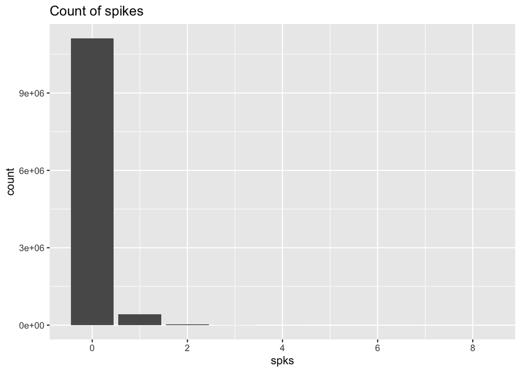

```r
ggplot(df) + geom_bar(mapping = aes(x=spks)) + labs(title = "Count of spikes")
```

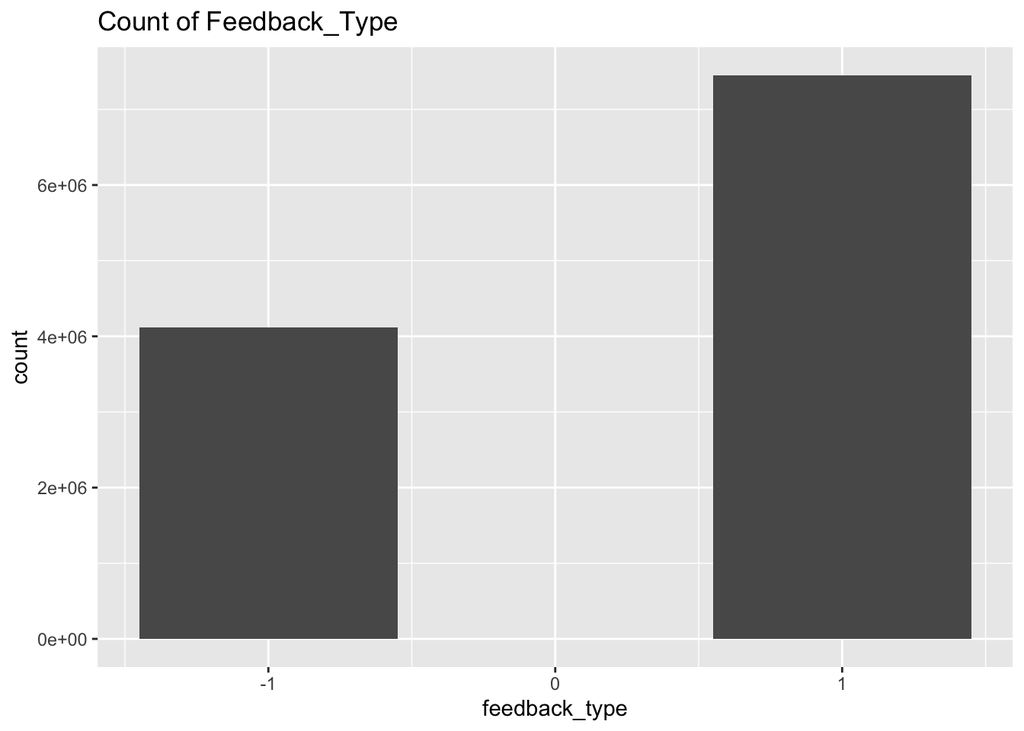

```r
ggplot(df) + geom_bar(mapping = aes(x=feedback_type)) + labs(title = "Count of Feedback_Type")
```

# Session 9: The most common brain_area was ORBm with 122. With the average spikes at 0.040. There were more success in this session than failures. The mice name was Hench.

```r
s9 = session[[9]]
summary(s9)
```

```
##                Length Class  Mode
## contrast_left  372    -none- numeric
## contrast_right 372    -none- numeric
## feedback_type  372    -none- numeric
## mouse_name       1    -none- character
## brain_area     788    -none- character
## date_exp         1    -none- character
## spks           372    -none- list
## time           372    -none- list
```

```r
spks = as.numeric(unlist(s9$spks))
time = as.numeric(unlist(s9$time))
brain_area = data.frame(s9$brain_area)
brain_area %>% count(s9$brain_area, sort = TRUE)
```

```
##    s9$brain_area   n
## 1           ORBm 122
## 2           VISl 104
## 3            CA1  90
## 4            CA3  86
## 5             LD  79
## 6            VPL  73
## 7             TT  55
## 8             TH  52
## 9             PL  50
## 10         VISam  38
## 11           LSr  33
## 12          root   6
```

```r
df = data.frame(spks, time, contrast_left = s9$contrast_left, contrast_right = s9$contrast_right, feedback_type = s9$feedback_type)
count(df, spks)
```

```
##   spks        n
## 1    0 11287523
## 2    1   413246
## 3    2    22206
## 4    3     2223
## 5    4      225
## 6    5       14
## 7    6        3
```

```r
mean(spks)
```

```
## [1] 0.03968423
```

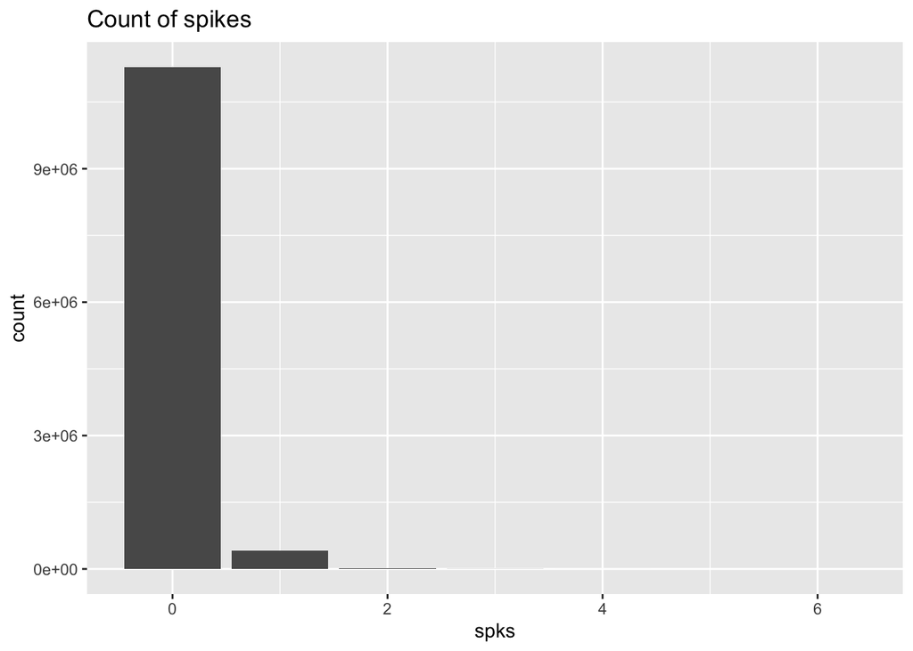

```r
ggplot(df) + geom_bar(mapping = aes(x=spks)) + labs(title = "Count of spikes")
```

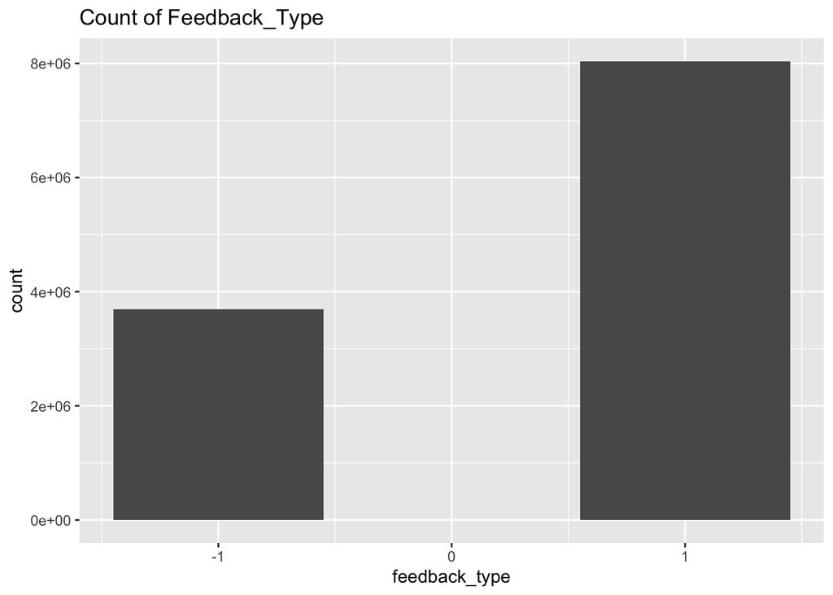

```r
ggplot(df) + geom_bar(mapping = aes(x=feedback_type)) + labs(title = "Count of Feedback_Type")
```

# Session 10: The most common brain_area was MB with 275. With the average spikes at 0.030. There were more success in this session than failures. The mice name was Hench.

```r
s10 = session[[10]]
summary(s10)
```

```
##                Length Class  Mode
## contrast_left   447   -none- numeric
## contrast_right  447   -none- numeric
## feedback_type   447   -none- numeric
## mouse_name        1   -none- character
## brain_area     1172   -none- character
## date_exp          1   -none- character
## spks            447   -none- list
## time            447   -none- list
```

```r
spks = as.numeric(unlist(s10$spks))
time = as.numeric(unlist(s10$time))
brain_area = data.frame(s10$brain_area)
brain_area %>% count(s10$brain_area, sort = TRUE)
```

```
##    s10$brain_area   n
## 1              MB 275
## 2             POL 154
## 3           VISrl 136
## 4            VISp 105
## 5            VISl  99
## 6             CA1  76
## 7              DG  73
## 8             MRN  72
## 9             GPe  63
## 10           POST  41
## 11           root  36
## 12            SCm  23
## 13           SCsg  19
```

```r
df = data.frame(spks, time,contrast_left = s10$contrast_left, contrast_right = s10$contrast_right, feedback_type = s10$feedback_type)
count(df, spks)
```

```
##   spks        n
## 1    0 20377980
## 2    1   537310
## 3    2    35896
## 4    3     3730
## 5    4      387
## 6    5       51
## 7    6        6
```

```r
mean(spks)
```

```
## [1] 0.02968839
```

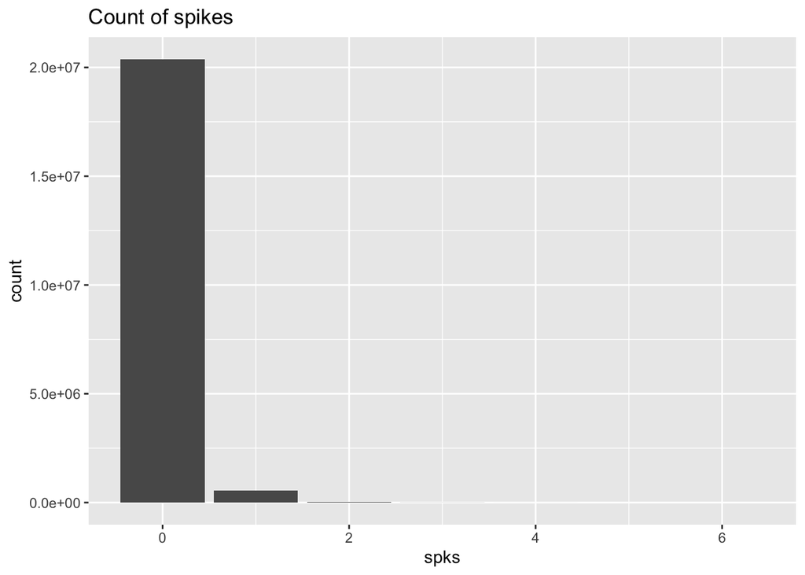

```r
ggplot(df) + geom_bar(mapping = aes(x=spks)) + labs(title = "Count of spikes")
```

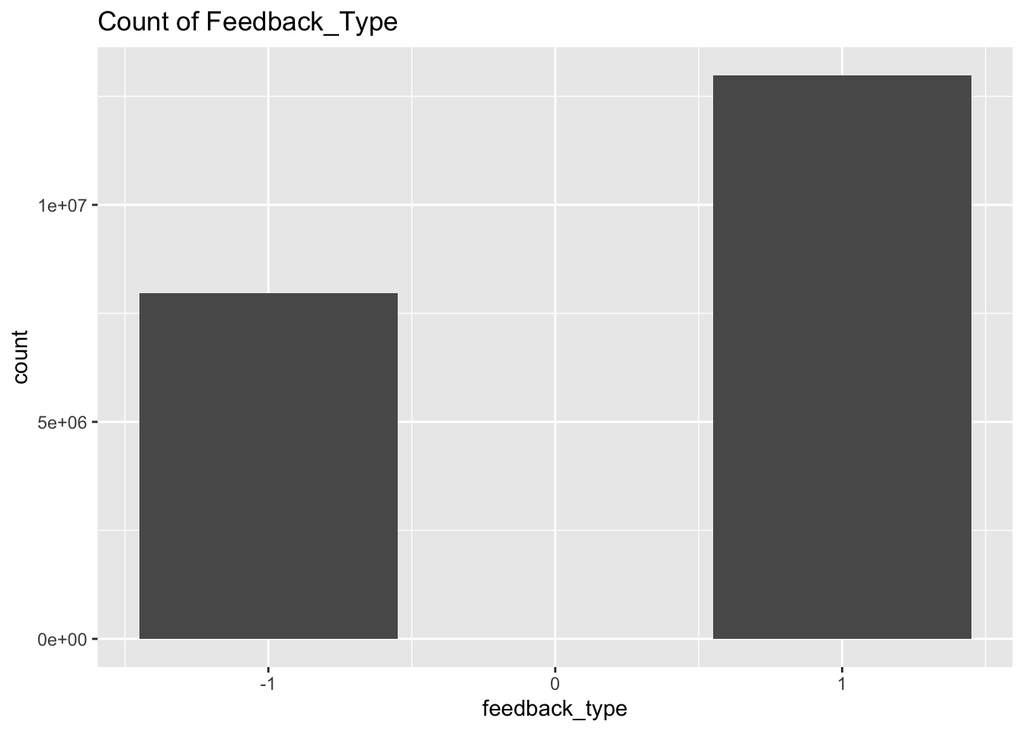

```r
ggplot(df) + geom_bar(mapping = aes(x=feedback_type)) + labs(title = "Count of Feedback_Type")
```

# Session 11: The most common brain_area was MOp with 447. With the average spikes at 0.031. There were more success in this session than failures. The mice name was Hench.

```r
s11 = session[[11]]
summary(s11)
```

```
##                Length Class  Mode
## contrast_left  342    -none- numeric
## contrast_right 342    -none- numeric
## feedback_type  342    -none- numeric
## mouse_name       1    -none- character
## brain_area     857    -none- character
## date_exp         1    -none- character
## spks           342    -none- list
## time           342    -none- list
```

```r
spks = as.numeric(unlist(s11$spks))
time = as.numeric(unlist(s11$time))
brain_area = data.frame(s11$brain_area)
brain_area %>% count(s11$brain_area, sort = TRUE)
```

```
##   s11$brain_area   n
## 1            MOp 447
## 2             CP 275
## 3            LSc  72
## 4             PT  45
## 5           root  14
## 6            LSr   4
```

```r
df = data.frame(spks, time, contrast_left = s11$contrast_left, contrast_right = s11$contrast_right, feedback_type = s11$feedback_type)
count(df, spks)
```

```
##   spks        n
## 1    0 11379019
## 2    1   324688
## 3    2    18513
## 4    3     1383
## 5    4      139
## 6    5       16
## 7    6        2
```

```r
mean(spks)
```

```
## [1] 0.03126224
```

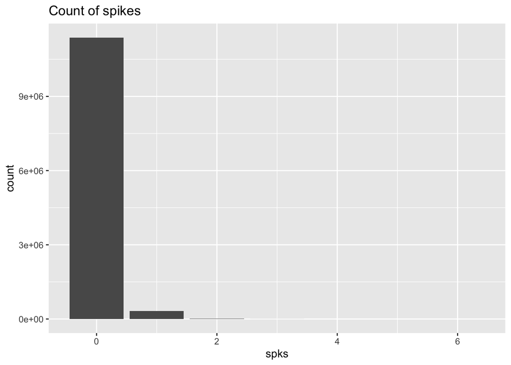

```r
ggplot(df) + geom_bar(mapping = aes(x=spks)) + labs(title = "Count of spikes")
```

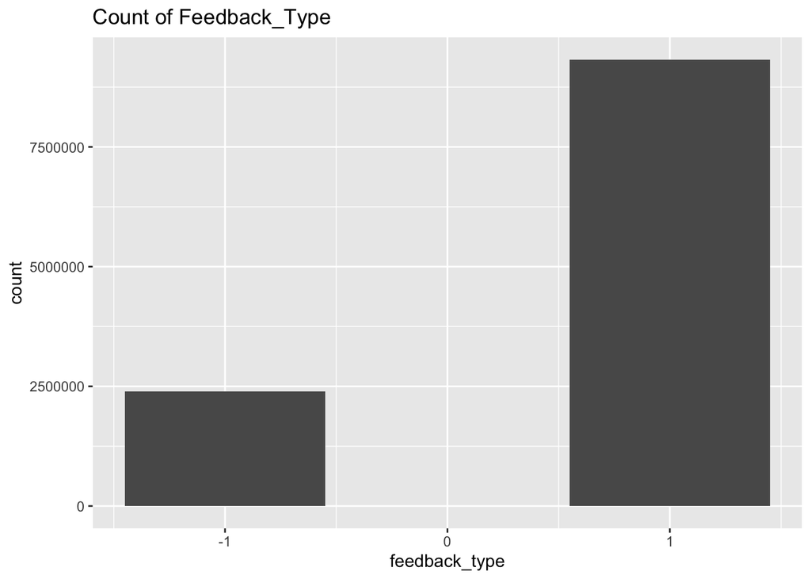

```r
ggplot(df) + geom_bar(mapping = aes(x=feedback_type)) + labs(title = "Count of Feedback_Type")
```

# Session 12: The most common brain_area was MD with 126. With the average spikes at 0.042. There were more success in this session than failures. The mice name was Lederberg.

```r
s12 = session[[12]]
summary(s12)
```

```
##                Length Class  Mode
## contrast_left  340    -none- numeric
## contrast_right 340    -none- numeric
## feedback_type  340    -none- numeric
## mouse_name       1    -none- character
## brain_area     698    -none- character
## date_exp         1    -none- character
## spks           340    -none- list
## time           340    -none- list
```

```r
spks = as.numeric(unlist(s12$spks))
time = as.numeric(unlist(s12$time))
brain_area = data.frame(s12$brain_area)
brain_area %>% count(s12$brain_area, sort = TRUE)
```

```
##    s12$brain_area   n
## 1              MD 126
## 2             SUB 105
## 3            root 100
## 4           VISam  79
## 5            VISp  66
## 6              DG  65
## 7              PL  56
## 8             CA1  50
## 9              LH  18
## 10            ACA  16
## 11            LGd  11
## 12            MOs   6
```

```r
df = data.frame(spks,time, contrast_left = s12$contrast_left, contrast_right = s12$contrast_right, feedback_type = s12$feedback_type)
count(df, spks)
```

```
##   spks       n
## 1    0 9115217
## 2    1  361454
## 3    2   15185
## 4    3     878
## 5    4      62
## 6    5       4
```

```r
mean(spks)
```

```
## [1] 0.04158162
```

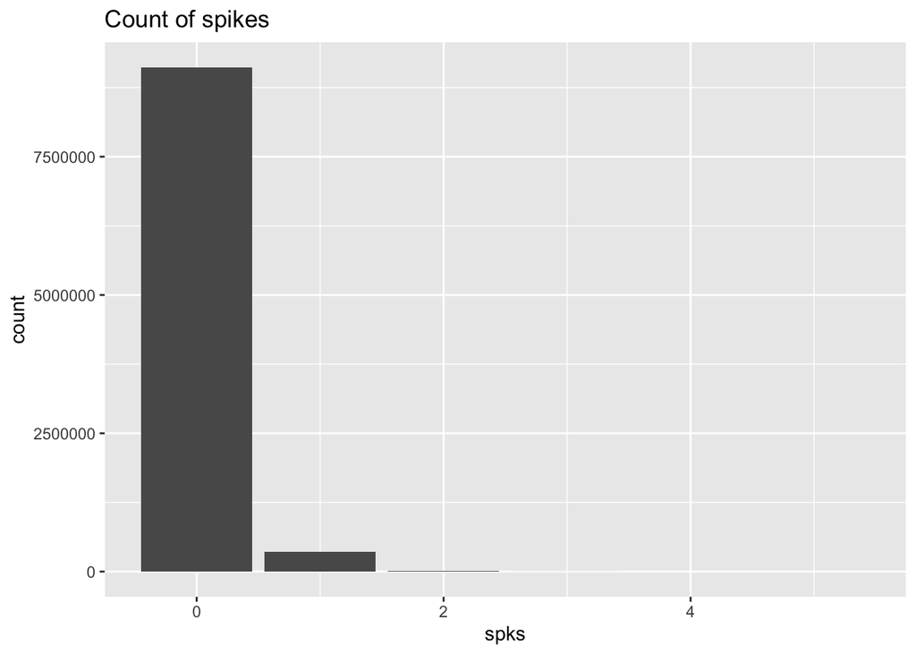

```r
ggplot(df) + geom_bar(mapping = aes(x=spks)) + labs(title = "Count of spikes")
```

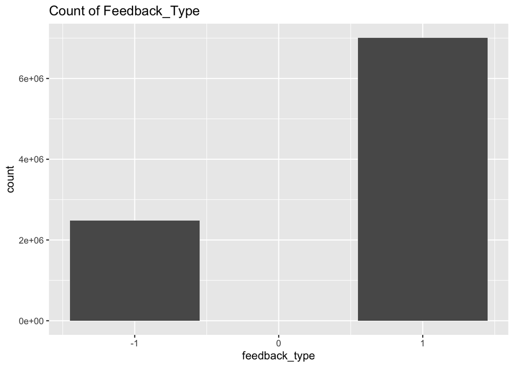

```r
ggplot(df) + geom_bar(mapping = aes(x=feedback_type)) + labs(title = "Count of Feedback_Type")
```

# Session 13: The most common brain_area was PL with 184. With the average spikes at 0.061. There were more success in this session than failures. The mice name was Lederberg.

```r
s13 = session[[13]]
summary(s13)
```

```
##                Length Class  Mode
## contrast_left  300    -none- numeric
## contrast_right 300    -none- numeric
## feedback_type  300    -none- numeric
## mouse_name       1    -none- character
## brain_area     983    -none- character
## date_exp         1    -none- character
## spks           300    -none- list
## time           300    -none- list
```

```r
spks = as.numeric(unlist(s13$spks))
time = as.numeric(unlist(s13$time))
brain_area = data.frame(s13$brain_area)
brain_area %>% count(s13$brain_area, sort = TRUE)
```

```
##    s13$brain_area   n
## 1              PL 184
## 2            root 173
## 3             LGd 150
## 4              MB  63
## 5             ACA  58
## 6              RN  58
## 7             MRN  51
## 8             MOs  46
## 9             SCm  45
## 10            CA1  34
## 11          VISam  34
## 12            SCs  32
## 13             MS  23
## 14             DG  17
## 15             ZI  15
```

```r
df = data.frame(spks,time,contrast_left = s13$contrast_left, contrast_right = s13$contrast_right, feedback_type = s13$feedback_type)
count(df, spks)
```

```
##   spks        n
## 1    0 11117887
## 2    1   635230
## 3    2    39537
## 4    3     2969
## 5    4      330
## 6    5       43
## 7    6        4
```

```r
mean(spks)
```

```
## [1] 0.06144201
```

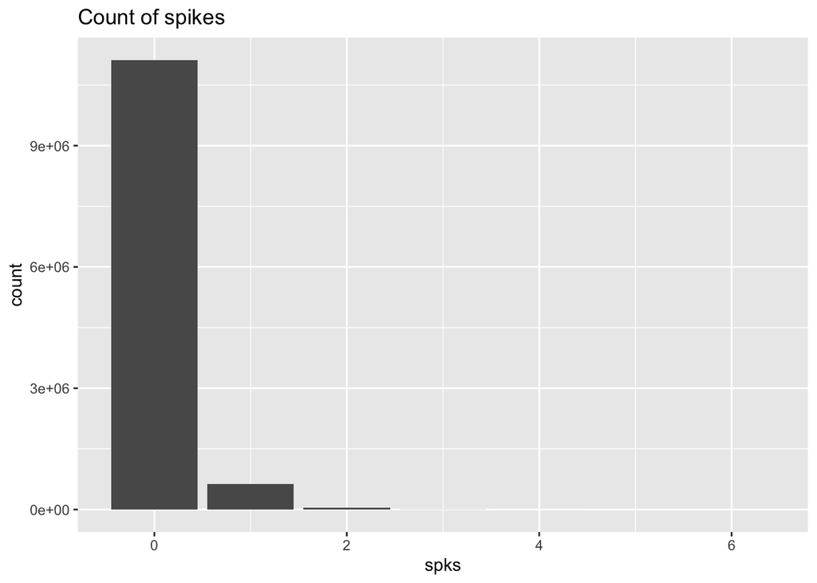

```r
ggplot(df) + geom_bar(mapping = aes(x=spks)) + labs(title = "Count of spikes")
```

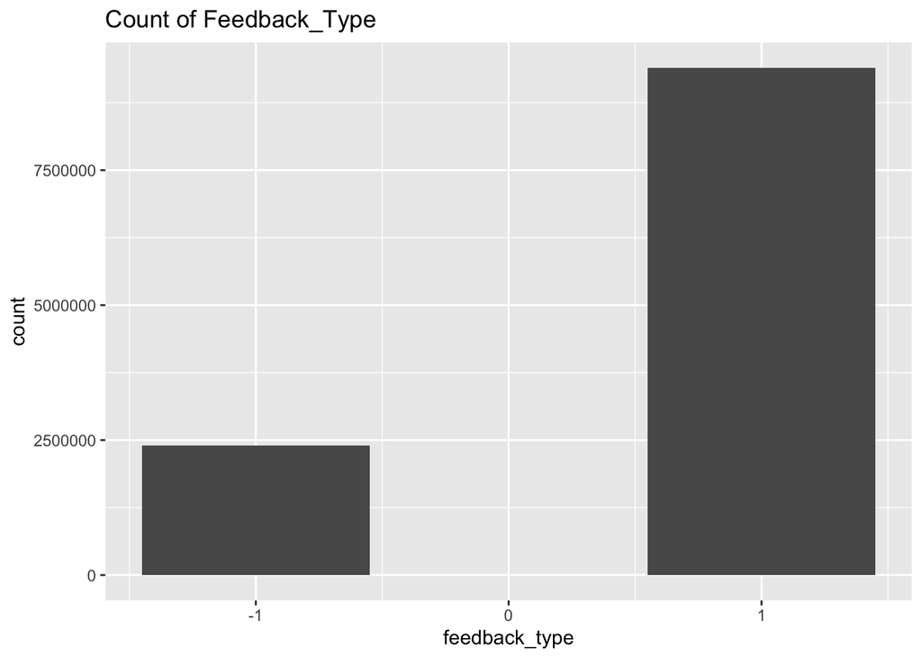

```r
ggplot(df) + geom_bar(mapping = aes(x=feedback_type)) + labs(title = "Count of Feedback_Type")
```

# Session 14: The most common brain_area was MOs with 186. With the average spikes at 0.025. There were more success in this session than failures. The mice name was Lederberg.

```r
s14 = session[[14]]
summary(s14)
```

```
##                Length Class  Mode
## contrast_left  268    -none- numeric
## contrast_right 268    -none- numeric
## feedback_type  268    -none- numeric
## mouse_name       1    -none- character
## brain_area     756    -none- character
## date_exp         1    -none- character
## spks           268    -none- list
## time           268    -none- list
```

```r
spks = as.numeric(unlist(s14$spks))
time = as.numeric(unlist(s14$time))
brain_area = data.frame(s14$brain_area)
brain_area %>% count(s14$brain_area, sort = TRUE)
```

```
##    s14$brain_area   n
## 1             MOs 186
## 2             ORB 170
## 3             CA1  99
## 4             RSP  85
## 5             MRN  72
## 6             SCm  48
## 7            VISp  42
## 8             SCs  37
## 9             PAG  14
## 10           root   3
```

```r
df = data.frame(spks, time, contrast_left = s14$contrast_left, contrast_right = s14$contrast_right, feedback_type = s14$feedback_type)
count(df, spks)
```

```
##   spks       n
## 1    0 7911115
## 2    1  183145
## 3    2    9436
## 4    3     571
## 5    4      49
## 6    5       3
## 7    6       1
```

```r
mean(spks)
```

```
## [1] 0.02516522
```

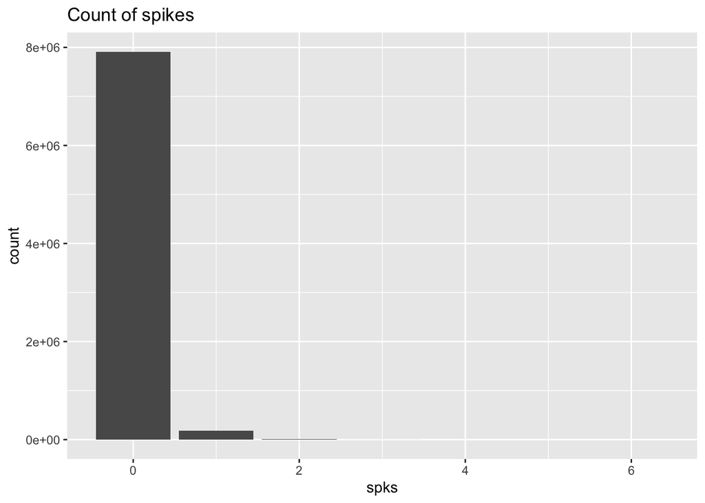

```r
ggplot(df) + geom_bar(mapping = aes(x=spks)) + labs(title = "Count of spikes")
```

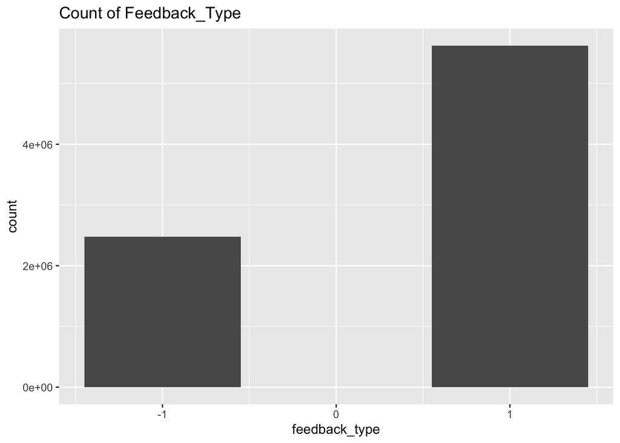

```r
ggplot(df) + geom_bar(mapping = aes(x=feedback_type)) + labs(title = "Count of Feedback_Type")
```

# Session 15: The most common brain_area was VPM with 162. With the average spikes at 0.037. There were more success in this session than failures. The mice name was Lederberg.

```r
s15 = session[[15]]
summary(s15)
```

```
##                Length Class  Mode
## contrast_left  404    -none- numeric
## contrast_right 404    -none- numeric
## feedback_type  404    -none- numeric
## mouse_name       1    -none- character
## brain_area     743    -none- character
## date_exp         1    -none- character
## spks           404    -none- list
## time           404    -none- list
```

```r
spks = as.numeric(unlist(s15$spks))
time = as.numeric(unlist(s15$time))
brain_area = data.frame(s15$brain_area)
brain_area %>% count(s15$brain_area, sort = TRUE)
```

```
##   s15$brain_area   n
## 1            VPM 162
## 2            GPe 142
## 3            BLA 132
## 4            LGd 121
## 5           root  83
## 6             ZI  55
## 7             MB  45
## 8            CA3   3
```

```r
df = data.frame(spks, time, contrast_left = s15$contrast_left, contrast_right = s15$contrast_right, feedback_type = s15$feedback_type)
count(df, spks)
```

```
##    spks        n
## 1     0 11590399
## 2     1   395711
## 3     2    19017
## 4     3     1413
## 5     4      247
## 6     5       63
## 7     6       24
## 8     7        3
## 9     8        2
## 10    9        1
```

```r
mean(spks)
```

```
## [1] 0.0366021
```

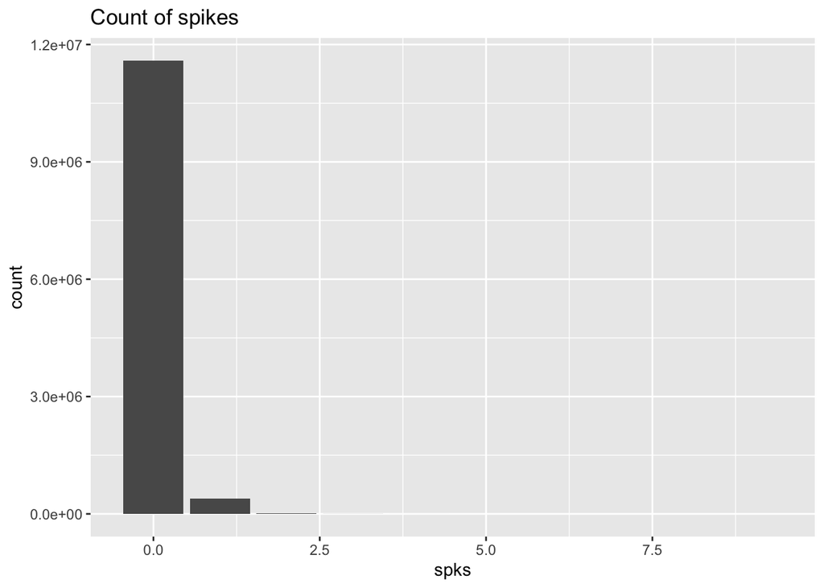

```r
ggplot(df) + geom_bar(mapping = aes(x=spks)) + labs(title = "Count of spikes")
```

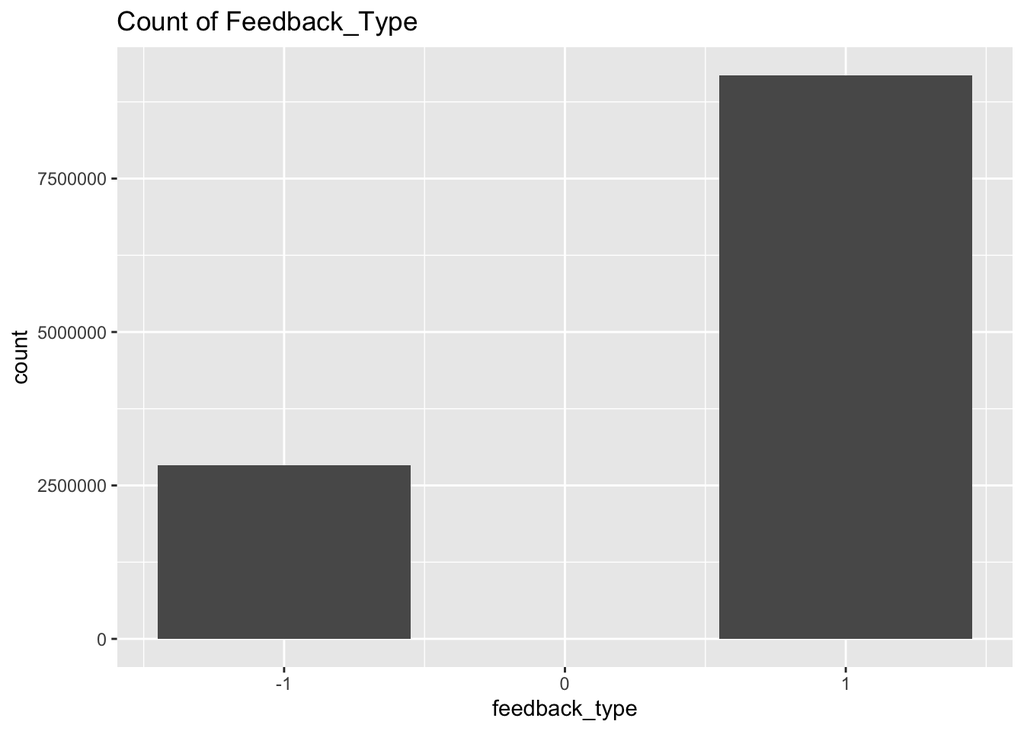

```r
ggplot(df) + geom_bar(mapping = aes(x=feedback_type)) + labs(title = "Count of Feedback_Type")
```

# Session 16: The most common brain_area was TH with 159. With the average spikes at 0.026. There were more success in this session than failures. The mice name was Lederberg.

```r
s16 = session[[16]]
summary(s16)
```

```
##                Length Class  Mode
## contrast_left  280    -none- numeric
## contrast_right 280    -none- numeric
## feedback_type  280    -none- numeric
## mouse_name       1    -none- character
## brain_area     474    -none- character
## date_exp         1    -none- character
## spks           280    -none- list
## time           280    -none- list
```